# 2 Modules

## 2.1 Data

### 2.1.1 Summary

[figure not shown]

The Data module is used to load, overview and manage datasets used by all other modules. The following is an example of how to format data for analysis in DAVe. To load the tutorial data select the Data module >> then Load on the sidebar >> Data type: examples >> load.

[figure not shown]

Loading the example data will add the `dave_` and `dave_var_meta` data sets which are examples of how to format the `numeric data`, `sample (row) meta data` and `variable (column) meta data`. Notice that `dave_` contains both information about the samples (columns A to C) which describes each of the measurements. For example, the first row contains information about the sample label: sample1, its class: non-diabetic and age: old. The measured values for sample1 start in column D (e.g. var1, var2, etc). The measured variables can correspond to any numeric data to be used for the analysis while the sample meta data contained in the first three columns can be used to construct `statistical` and `machine learning models` and annotate `visualizations`.

[figure not shown]

To merge the sample meta data and numeric data we need to specify the index shared by the `dave_` and `dave_var_meta` data components. The `index` corresponding the mapping between the two data sets is defined in the `ID` column in `dave_var_meta`. Note: while this column can have any name, it needs to contain the exact column name(s) specified for the numeric data in `dave_`. For example, the first row in `dave_var_meta` describes the numeric variable named var1 in the `dave_` data. Important: it is recommended to use strings with no spaces and special characters (e.g. var1 or measurement_1) instead of numeric values to name the numeric data and the index.

Next use the Preprocess module to merge the two dataset.

### 2.1.2 Reference

[figure not shown]

This module is used to overview and manage data and metadata objects.

### Data management

To get started format your data into two parts as shown below and then follow allong with the instructions in `preprocess` >> `merge` to create an analysis ready data object.

### `Methods`

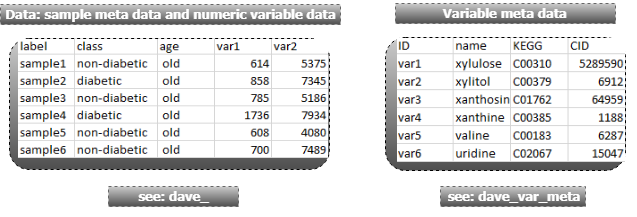

#### The data should be formated into two parts 1) the main data containing sample descriptions and numeric variable data and 2) variable meta data.

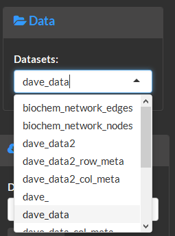

#### The main components include the ability to select and view the data.

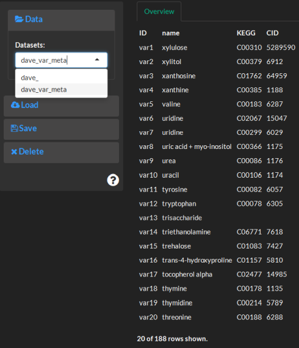

#### Selected data is shown in the overview.

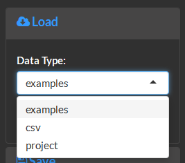

#### Data can be uploaded in the following formats: .csv, project or example.

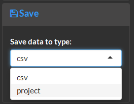

#### Data can be saved as a .csv for download or a project which can be loaded later.

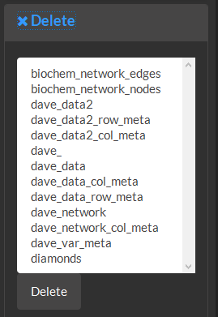

#### Deletion of data objects can be done here.

## 2.2 Preprocessing

### 2.2.1 Summary

#### 2.2.1.1 Merge

[figure not shown]

The preprocess merge module is used to select row meta data components from `dave_` and specify the `index` to merge the `numeric data` with `dave_var_meta` which contains information about each of the columns or measurements.

[figure not shown]

Select the Samples menu in the sidebar then the column names for the variables which contain the sample meta data. Next use the Variables menu to select the variable meta data: `dave_var_meta` and specify the column name for the `index`: ID to merge with `dave_`.

[figure not shown]

Note: in some cases, you may only have information about the variables and no numeric sample data. For example, you could have already calculated statistical significance for variables or have other information you want to use to conduct pathway, network or other analyses. In this case, change the `Data type` in the sidebar to `variables`.

Next click the `calculate` button to merge the data. This will output the merge methods used and results.

[figure not shown]

The `plot` and `explore` tabs can be used to visualize the results.

[figure not shown]

Next, select `Save` menu in the sidebar, choose a name for your new data and save the data to use in other analyses. This will add the merged data to the global environment which then can be used for further analyses.

[figure not shown]

#### 2.2.1.2 Filter missing values

[figure not shown]

The preprocess missing is used to overview, remove and impute missing values in the numeric data. Important : rows or columns a with too many missing values or a missing pattern biasing a factor in the sample meta data should be removed or imputed.

[figure not shown]

The `Filter` menu in the sidebar can be used to evaluate missing values across all variables. Missing values can be evaluated based on a grouping variable in the `sample meta data` e.g. class: diabetic or non-diabetic to remove missing patterns which can bias further analyses comparing the two groups. The selection shown above will remove any variable(s) which contain ≥ 50% missing values for either diabetic or non-diabetic samples.

Select calculate and then use the `plot` and `explore` tabs to visualize the results.

[figure not shown]

The above visualization displays the persent missing valuse in variables overall and for each group.

[figure not shown]

The above visualization shows sample(s) with missing values. Important: the remaining missing values should be replaced or imputed by selecting the `impute` menu in the sidebar.

[figure not shown]

[figure not shown]

Once all the methods are set next use the `calculate` button to view the results.

[figure not shown]

Use the sidebar `save` menu to save the results for further analyses. Note: don’t change the name of the data to easily keep all module results combined.

[figure not shown]

### 2.2.2 Reference

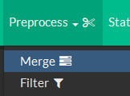

This module is used to merge, filter and prepare the data for analysis.

### Merge

`Merge` is used to identify experimental design factors and merge numeric and variable metadata.

### `Methods`

#### Select sample meta data (e.g. non-numeric descriptors of the experimental design) which will be added to the `_row_meta` object and made available to use in visual mapping and analysis/calculation controls.

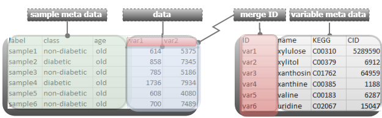

#### Identify and row meta data.

[figure not shown]

#### Identify and add column or measurement meta data, wherein ID sets the unique row identifier (e.g. row number).

[figure not shown]

### `Results`

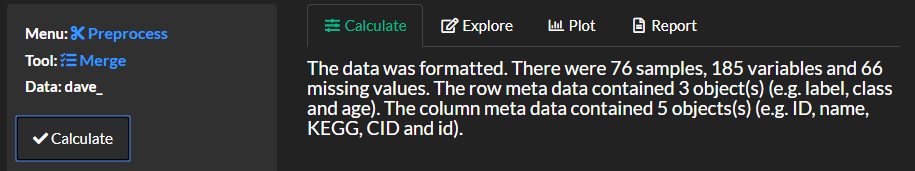

### `Explore and Plot`

#### Visualize a summary of the merged data.

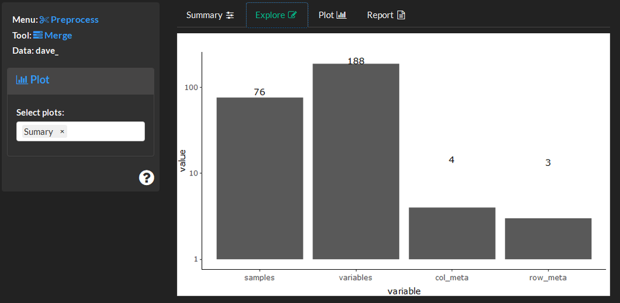

### `Save`

#### Use `save` to create a data set which will be used for further analyses.

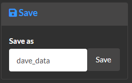

### Filter

`Filter` can be used to identify and remove variables with missing values. Specify a factor `group` of interest and the `missing cutoff` or percent acceptible missing for each level in the `group`. It is also useful to remove non-informative varibles or those with a standard deviation of zero (`remove zero variance`).

### `Methods`

#### Remove error prone variables with too many missing values or zero variance.

[figure not shown]

#### Optionaly select groups of samples to evaluate missing values.

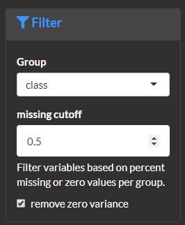

#### Impute all missing values in the data. Replace based on a variery of sumaries based on the presnt values.

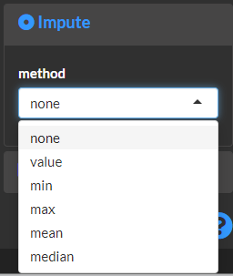

### `Results`

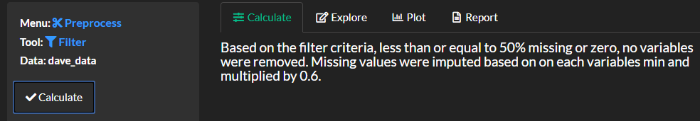

### `Explore and Plot`

#### View missing data for each sample and variable, overall and by class. Missing or zero variables shown in red are arranged based on their sample (row) and variable (column) number.

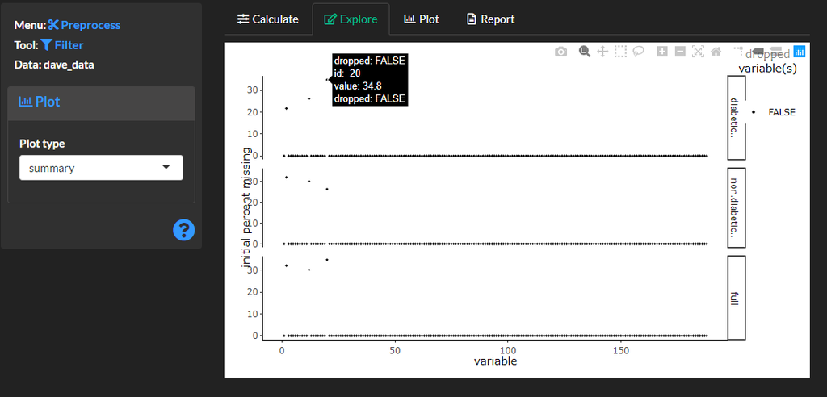

#### Flagged variables, or those containing greater or equal percent zero or missing values than the `missing cutoff` are shown in red for each level of a group `group`.

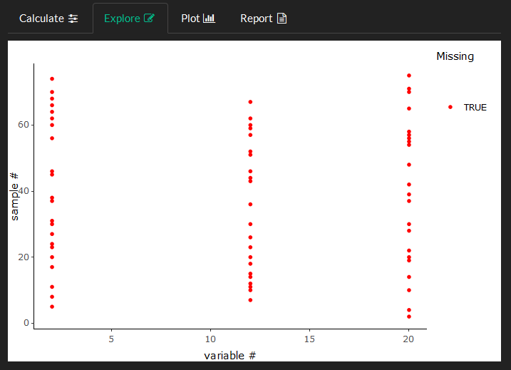

## 2.3 Statistics

### 2.3.1 Reference

## **Statistics**

This module is used to carry out statistical analyses, identify and filter the data based on significant differential expression.

### Kruskall-Wallis (two-class comparison of means)

This is a non-parametric test for differences in means between two groups. This test does not assume normality and can be robust to outliers when testing for differences in means between two groups with small samples sizes. This module can also be used to identify differentially expressed variables between groups and create filtered datasets based on the test p-values.

### `Methods`

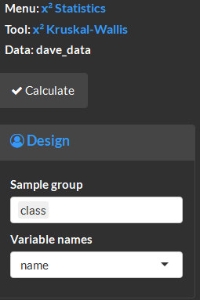

#### Identify experimental design factor(s) to use for tests and specify variable meta data.

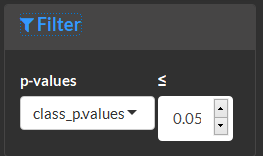

#### Select significance level (alpha) to use in visualizations and filter the data.

### `Results`

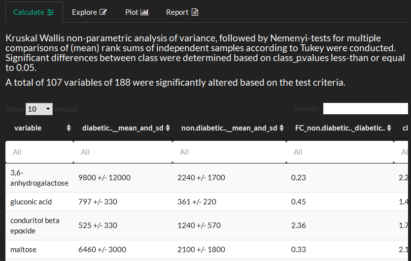

### `Explore and Plot`

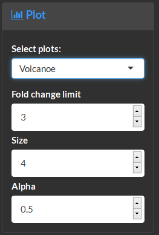

#### Create a volcano plot to visualize the relationship between variable fold-changes between groups and test p-values.

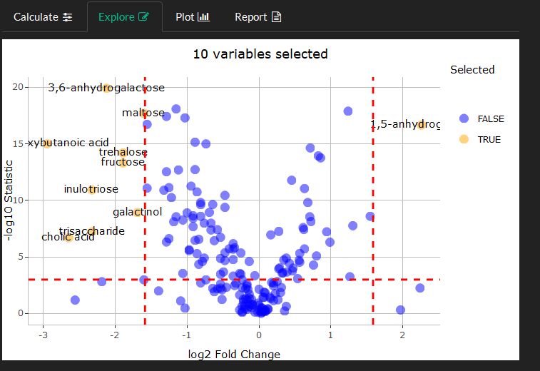

#### Identify variables with large fold-changes between groups and low p-values.

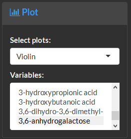

#### Select one or many variables to generate violin density plots.

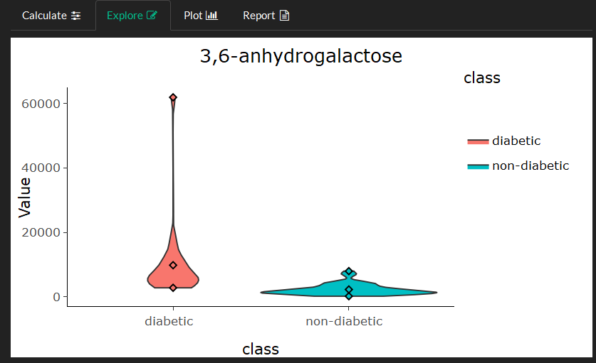

#### Explore variable distributions among groups.

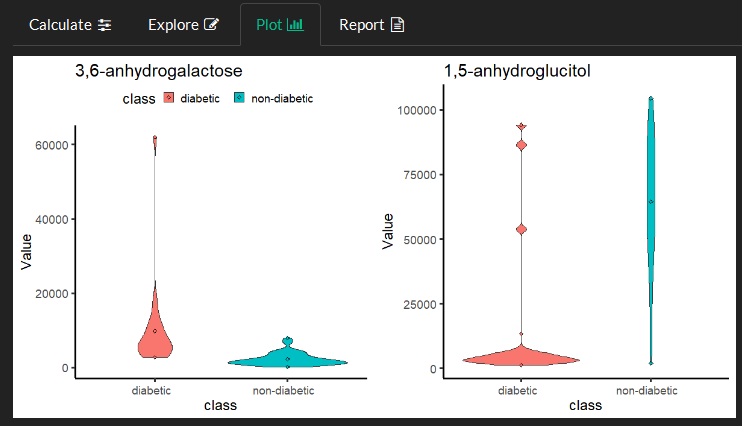

#### Use `plot` to view many variables and overview the plot style for the `report`.

### `Save`

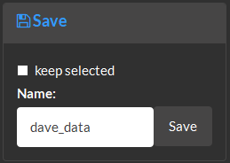

#### Save results and optionally remove non-significant variables by selecting `keep selected`.

## 2.4 Clustering

### 2.4.1 Reference

## **Cluster**

This module is used to identified clusters of related groups of samples and variables.

### Hierarchical cluster analysis (HCA)

This module is used to carry out hierarchical cluster analysis (HCA) on samples and variables. HCA distance and agglomeration methods can be used to organize the input based on similarity and identify clusters of closely related samples or variables based on the raw data or correlations.

### `Methods`

#### Use the `nodes` menue to specify if samples or variables will be clustered. You can additionally specify `names` used for labels and `annotations` used for displaying group metadata.

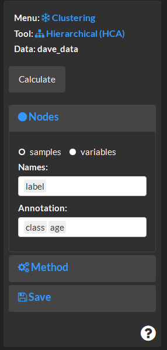

#### The `methods` menue is used to optionally specify a correlation method, set HCA distance and linkage methods and select the number of clusters.

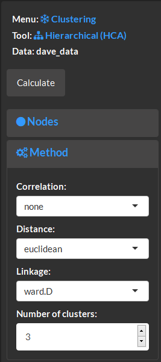